# Mass Shootings and Their Impact on Retail

Converted from PDF `Chiong-MassShootingsRetail-2025-MKSC.pdf` · 11 pages · anchors: page `#pN`, block `#pN-bK`

Page 1

[figure not shown]

NOTE: figure/graphic rendered as an image from the PDF; its content is not machine-readable text. Caption (if any) follows as the next block.

**text found inside the figure**

Marketing Science

Publication details, including instructions for authors and subscription information: http://pubsonline.informs.org

Mass Shootings and Their Impact on Retail

Khai Chiong, Seung Mok (Simon) Kim, TI Tongil Kim

To cite this article: Khai Chiong, Seung Mok (Simon) Kim, TI Tongil Kim (2025) Mass Shootings and Their Impact on Retail. Marketing Science 44(5):985-994. https://doi.org/10.1287/mksc.2024.0752

This work is licensed under a Creative Commons Attribution-NoDerivatives 4.0 International License. You are free to download this work and share with others commercially or noncommercially, but cannot change in any way, and you must attribute this work as “*Marketing Science*. Copyright © 2025 The Author(s). https://doi.org/10.1287/ mksc.2024.0752, used under a Creative Commons Attribution License: https://creativecommons.org/licenses/bynd/4.0/.”

Copyright © 2025 The Author(s)

Please scroll down for article—it is on subsequent pages

Page 2

### **Mass Shootings and Their Impact on Retail**

#### **Khai Chiong,<sup>a,</sup>* Seung Mok (Simon) Kim,<sup>a</sup>TI Tongil Kim<sup>a</sup>**

**a**Naveen Jindal School of Management, University of Texas at Dallas, Richardson, Texas 75080 *Corresponding author **Contact:** khai.chiong@utdallas.edu, https://orcid.org/0000-0002-6713-8907 (KC); kim@utdallas.edu, https://orcid.org/0000-0002-8855-7086 (SM(S)K); ti.kim@utdallas.edu, https://orcid.org/0000-0003-3277-4337 (TITK)

[figure not shown]

NOTE: complex table shown as an image of the PDF; the text below is a rough machine extraction and may be mis-aligned.

**extracted text (unreliable layout)**

**Keywords: retailing** <sup>•</sup> **gun violence** <sup>•</sup> **natural experiment** <sup>•</sup> **staggered difference-in-differences** <sup>•</sup> **causal inference**

**1. Introduction** Mass shootings in the United States have become more frequent in recent years. Between 2016 and 2019, the country averaged 371 mass shootings per year. This number rose to 650 annually between 2020 and 2023.<sup>1</sup>

The growing prevalence of mass shootings presents challenges for retail businesses. First, retail locations such as shopping malls are common targets due to their high foot traffic,<sup>2</sup> making them the most common setting, followed by restaurants and bars.<sup>3</sup> Second, nearly two-thirds of retailers have identified mass vio lence or active assailant events as a growing concern (National Retail Federation 2023). In response to the recent uptick in mass shootings, some public compa nies have started assessing and disclosing the potential financial impact of these events in their annual reports.<sup>4</sup> Although the human toll of these events is evident, their economic impact on retail businesses is not known. We present the first systematic investiga tions into the economic cost of mass shootings to retail businesses and how they impact consumers.

We combine U.S. mass shooting incident data with store-level credit and debit card transaction data that are matched to the location of the incident. Because mass shootings are salient and plausibly random events, we implement a difference-in-differences (DID) strategy around the timing and location of mass shootings to esti mate their causal impact on consumer shopping behav ior. Specifically, we compare the performance of stores that encountered a mass shooting (i.e., treatment group) to that of stores that did not (i.e., control group).

We examine the record of all mass shootings in the United States that occurred at or near a retail location between January 2022 and June 2023, totaling 486 inci dents. By tracking the performance of 16,431 individual retail businesses over a 30-month period, our DID esti mates show that, on average, affected stores experi enced a 12.9% reduction in transactions and a 4.8% decrease in order size, leading to an overall 18.7% decrease in revenue. These findings are corroborated by foot traffic data, which show significant reductions in both foot traffic and dwell time at the affected stores

985

#### **MARKETING SCIENCE Vol. 44, No. 5, September–October 2025, pp. 985–994**

#### **ISSN 0732-2399 (print), ISSN 1526-548X (online) https://pubsonline.informs.org/journal/mksc**

Page 3

after incidents. When examining store closures due to mass shootings, we find that 16.7% of affected stores shut down. However, certain types of stores, such as branded and franchised stores, are less likely to close.

We also estimate how the impact of mass shootings varies with distance from the incident. We show that mass shootings impact not only directly affected stores but also businesses within a 1.25-mile radius. The impact, however, diminishes with distance: stores closest to the incident (within 0.1 miles) face an average revenue decline of 24.6%, whereas those further away (between 1 and 1.25 miles) see a smaller decline of 8.7%. Beyond 1.25 miles, the effect is not statistically significant.

Accounting for store closures and using DID esti mates based on the proximity of stores to incidents, we estimate the nationwide economic cost of mass shoot ings at $27 billion annually in forgone revenue for affected retailers, equivalently erasing 0.5% of the U.S. retail gross domestic product (GDP) each year.

The decrease in foot traffic and dwell times at impacted stores following an incident suggests that heightened consumer fear and safety concerns may lead consumers to avoid or curtail time spent there. Further supporting this, we observe heterogeneous effects by business type, with nonessential stores more affected than essential ones, evidence of channel substi tution from in-person to online shopping, and modera tion by local exposure to gun-related violence, where stores in areas with higher firearm mortality experience smaller impacts.

We conduct a battery of additional analyses to check the validity and robustness of our results. First, we use recent advances in staggered DID (Callaway and Sant’Anna 2021) to account for the variation in the treatment timing of mass shootings. We also find con sistent results across various functional form assump tions and sample selection criteria.

We offer several managerial and policy implications. First, this study is the first to document and quantify the economic cost of mass shootings on retail businesses, providing benchmarks for understanding these risks. Second, our findings show that the impact of mass shoot ings extends beyond directly targeted stores, affecting businesses within a 1.25-mile radius. With the increasing number of mass shootings, our findings offer a novel per spective on the national discourse by highlighting the geographically widespread economic impacts on busi nesses and underscoring the need for attention from pol icymakers to address it. Finally, we demonstrate the use of online channels in bolstering store resilience against adverse shocks such as mass shootings.

#### **2. Related Literature** Our study adds to three streams of literature. First, our study contributes to the literature examining the effect

of mass shootings on consumer psychology. Hughes et al. (2011), Soni and Tekin (2023), and Lagerborg et al. (2023) highlight mass shootings’ prolonged negative impact on the community and individual emotional well-being, as well as consumer confidence levels. Studies have also shown that fear of mass shootings reduces leisure activities (Clark and Stancanelli 2017) and discourages consumers from attending public events or going to the mall (American Psychological Association 2019). However, these studies primarily rely on surveys. In contrast, we employ detailed data on customer visits and spending at retail stores to investigate the impact of mass shootings on businesses.

Second, our study builds on literature examining the financial and economic consequences of mass shoot ings. Brodeur and Yousaf (2025) and Lagerborg et al. (2023) report the adverse effect of mass shootings on local economies, including increased unemployment rates and decreased industrial production. Other stud ies, like Gopal and Greenwood (2017), Karan (2019), and Sakariyahu et al. (2023), focus on repercussions for financial markets. Shaik et al. (2023) study the eco nomic impact of fatal school shootings on grocery purchases and home values. Although these studies primarily consider broader macroeconomic indicators at the county or national levels, our study takes a dif ferent approach by examining the performance metrics of individual retail stores using location-based credit and debit card transaction data.

Finally, our study contributes to policy discussions on gun violence and the availability of firearms. Luca et al. (2020) find that mass shootings have an outsized influ ence on policy responses, leading to a 15% increase in firearm bills introduced in a state in the following year. Recent research, such as Balakrishna and Wilbur (2022), Kim and Wilbur (2022), and Moshary et al. (2023), inves tigates the firearm market by analyzing sales and con sumer demand for firearms. Our study adds to this dialogue by quantifying the economic cost of mass shootings.

**3. Data** We utilize three main data sets: (1) mass shooting data from the Gun Violence Archive (GVA), (2) debit and credit card transactions data from SafeGraph Spend, and (3) foot traffic data from Advan Patterns.

**3.1. Mass Shooting Data: GVA** We obtain data on mass shooting incidents from the GVA,<sup>5</sup> a not-for-profit, independent research group. The GVA collects daily data from more than 7,500 sources, including law enforcement, media, govern ment, and commercial sources, providing near-real- time information on gun violence incidents in the United States. Following the GVA’s definition, a mass

**Chiong, Kim, and Kim:** *Mass Shootings and Their Impact on Retail* 986 Marketing Science, 2025, vol. 44, no. 5, pp. 985–994, © 2025 The Author(s)

Page 4

shooting is defined as an incident in which four or more people are shot, excluding the shooter. For each incident, the archive catalogs the date, location, and number of fatalities and injuries.

**3.2. Location-Based Retail Spending Data: SafeGraph Spend** SafeGraph Spend collects anonymized debit and credit card transactions from a panel of around 10.6 million consumers, spanning more than 1.1 million business locations in the United States.<sup>6</sup> Each transaction is geo- coded and linked to a brick-and-mortar business loca tion. The data provide a spatially granular view into American commerce, allowing us to see how much customers spend at each place and month.<sup>7</sup> Online Appendix C.1 offers additional background informa tion on SafeGraph Spend and highlights its representa tiveness by comparing it to U.S. Census statistics, including the number of customers and income levels.

SafeGraph Spend provides business names, precise locations, and monthly performance metrics for each establishment. We focus on three performance mea sures at the store-month level: (1) *Total Revenue*, repre senting the total dollar amount spent by customers; (2) *Number of Transactions*, indicating the total number of credit and debit card transactions; and (3) *Order Size*, measured as the median dollar amount spent per transaction.<sup>8</sup>

We categorize stores using the North American Industry Classification System (NAICS) codes, covering

businesses such as restaurants, bars, grocery stores, gas stations, clothing stores, and pharmacies. Tables C.1 and C.2 in the Online Appendix provide a list of these cate gories using four-digit and six-digit NAICS codes, respectively, along with the count of stores in our data.

**3.3. Estimation Sample Construction** This section outlines how the GVA and SafeGraph Spend are merged to identify stores affected by mass shootings (i.e., treated stores), followed by details on finding comparable stores (i.e., control stores) via a matching process.

**3.3.1. Sample of Mass Shootings.** From the GVA, we obtained all mass shooting incidents in the United States between January 2022 and June 2023 that occurred within 0.25 miles of a retail store in SafeGraph Spend.<sup>9</sup>

This resulted in a total of 486 incidents, which we term retail mass shootings: incidents occurring within walk ing distance of a retail location. Figure 1 depicts the geo graphical distribution of these incidents, indicating that mass shootings are frequent in population centers. In terms of the site of mass shootings in our sample, retail/commercial was the most frequent incident loca tion (41.7%), followed by residential (25.1%) and mixed- use commercial/residential (23.4%). Our sample also includes other incidents, such as school shootings, drive- by shootings, shootouts, robberies, and domestic vio lence. Table C.3 in the Online Appendix provides a more detailed characterization of these incidents.

**Figure 1.** Map of Retail Mass Shootings Between January 2022 and June 2023

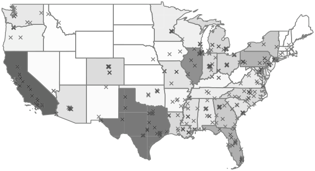

NOTE: figure/graphic rendered as an image from the PDF; its content is not machine-readable text. Caption (if any) follows as the next block.

*Notes.* This figure shows mass shooting incidents in our sample that occurred between January 2022 and June 2023. Each × on the map denotes the location of a mass shooting incident.

**Chiong, Kim, and Kim:** *Mass Shootings and Their Impact on Retail* Marketing Science, 2025, vol. 44, no. 5, pp. 985–994, © 2025 The Author(s) 987

Page 5

Our sample covers several high-profile retail mass shootings, such as the shooting at a Tops Friendly Supermarket in Buffalo, NY, that killed 10 and injured three; the shooting at the Allen Premium Outlets that killed nine and injured seven; and the shooting at Greenwood Park Mall in suburban Indianapolis that killed four and injured two.

On average, a mass shooting results in 0.97 deaths (excluding the shooter) and 4.29 injuries, with the median values of one death and four injuries in our sample.

**3.3.2. Treated Stores and Descriptive Evidence.** Based on our sample of mass shootings, 486 incidents occur ring within walking distance of 0.25 miles from a retail store, we then identified 3,323 affected (treated) stores within 0.25 miles of these incidents. We identify these stores by calculating the distances between the stores and the locations of mass shooting incidents, using the coordinates provided in the two data sets.

Our SafeGraph Spend data cover the period from July 2021 to December 2023. By examining mass shoot ing incidents between January 2022 and June 2023, we ensure that each treated store has at least six months of pre- and posttreatment observations.

Table 1 provides the summary statistics of the trea ted stores’ retail performances. By comparing the aver age values before and after mass shooting incidents, we observe that the total revenue decreases by 13% after the incident. Similarly, the average number of transactions and the order size decreases by 9.6% and 6.8%, respectively. Figure A.1 in the Online Appendix, which plots the trend of average weekly revenues before and after a mass shooting incident, also exhibits a noticeable decrease after an incident.

**3.3.3. Comparable Control Stores via Matching.** To facilitate a DID estimation of the causal impact of mass shootings, we identify unaffected comparable control stores using the following steps.

First, we define the pool of eligible control units to be stores located between 10 and 94.7 miles from the inci dent location. The minimum distance of 10 miles is to ensure that the control stores are not too close to risk spillover effects from the treated stores,<sup>10</sup> whereas the

maximum distance of 94.7 miles is to ensure similarity in the underlying macroeconomic conditions for each control and treated pair. Second, for each treated store, we employ exact matching to find the set of control stores of the same business type (based on NAICS). For instance, a treated pharmacy is matched with other pharmacies as its control group. Third, for each treated store, we apply Mahalanobis distance matching to find five control stores that are most similar in terms of per formance measures preshooting.

The final sample is a balanced panel data of 16,431 retail stores (3,323 treated and 13,108 control stores) between July 2021 and December 2023, totaling 492,930 store-month observations. Online Appendix B provides further details and justification of the matching proce dure and demonstrates a covariate balance between treated and control stores. Online Appendix D.2 dis cusses the robustness of our results with respect to alter native matching methods.

**3.4. Foot Traffic Data** We augment our stores’ transaction data with foot traf fic data from Advan Patterns.<sup>11</sup> These data provide monthly visit counts to places and points of interest based on a panel of mobile devices, including visit fre quency and duration. In particular, it shares the same store identifier with SafeGraph Spend, allowing us to examine the same set of treated stores over the same time period (balanced panel). We focus on the following store-month outcomes: (i) *Visits*, representing the total number of visits to the location, and (ii) *Dwell Time*, indicating the median duration of visits (in minutes).

**4. Empirical Analyses** We separately analyze the effect of mass shootings on two types of stores: (1) operating stores and (2) closed stores. We consider a store as *closed* if we observe three or more consecutive months of closure after the inci dent and *operating* otherwise. Of the 3,323 treated stores, 554 (16.7%) are closed, with the remainder being operating stores.

First, we analyze the effect of mass shootings on oper ating stores’ performance metrics and foot traffic (Sec tion 4.1) and examine store closure (Section 4.2). We then estimate how the effect decays over geographic

**Table 1.** Descriptive Statistics of Treated Stores

|  | Beforemassshooting | Aftermassshooting |  |
| --- | --- | --- | --- |
| Outcome | Mean(standarderror) | Mean(standarderror) | Difference(%) |
| Totalrevenue($) | 61315(952) , . . | 53367(848) , . . | 1296 . |
| No. of transactions | 17979(21) . . | 16250(20) . . | 962 . |
| Ordersize($) | 3335(03) . . | 3107(03) . . | 683 . |

NOTE: table converted from PDF layout to HTML text; cell boundaries are reconstructed. See PDF if exact alignment matters.

*Notes.* We winsorized the raw data at the 99.9th percentile for this table. The total number of treated observations is 99,690, that is, 3,323 treated units over 30 months. Of these observations, 43,944 are preperiod, and 55,746 are postperiod. SafeGraph’s panel samples a fraction of the store’s total revenue and thus does not reflect the total revenue.

**Chiong, Kim, and Kim:** *Mass Shootings and Their Impact on Retail* 988 Marketing Science, 2025, vol. 44, no. 5, pp. 985–994, © 2025 The Author(s)

Page 6

distance (Section 4.3). Finally, we arrive at an estimate of the economic cost of mass shootings to the retail industry in Section 4.4.

**4.1. Main Effect** Our main empirical specification is a two-way fixed- effect (TWFE) DID regression:

*Yit*  β · *PostTreatit* + δ*i* + τ*t* + *ɛit:* (4.1)

The dependent variable *Yit* represents the outcome measure of store *i* in month *t*, specifically the logarith mic functions of total revenue, the number of transac tions, order size, foot traffic, and median dwell time. The variable *PostTreatit* equals one if store *i* is affected by a mass shooting incident and if *t* is after the incident; otherwise, it is zero. The coefficient β is our parameter of interest. We include fixed effects for stores, δ*i*, and time periods, τ*t*, to account for store-specific and macro economic factors that may affect the outcome. Standard errors are clustered at the incident level to account for correlations among the error terms of different stores affected by the same mass shooting incident.

The standard TWFE DID framework assumes that treatment occurs at the same time for all treated units. However, mass shootings occur at different times, resulting in staggered treatment timing. As an alterna tive model, we implement the staggered DID estimator of Callaway and Sant’Anna (2021) (CS).

Both the TWFE and the CS estimates show that mass shootings have a significant negative effect on revenue, number of transactions, and order size (Panel A in Table 2). In particular, affected stores on average expe rience a 19% reduction in revenue, 13% lower transac tions, and 5% smaller order size, compared with the

control stores. The magnitudes of coefficients from both TWFE and CS are comparable.

In Panel B of Table 2, we examine the effect of mass shootings on consumer visits and their median dwell time. We find that mass shootings significantly decrease foot traffic to affected stores by 23% (column 7 of Table 2). Additionally, the median dwell time of visitors at these stores decreases by 18%. The reduced dwell time explains the negative impact of mass shootings on both intensive and extensive margins: with less time spent in stores, indi viduals purchase fewer items per visit, leading to the smaller order sizes observed in Table 2.<sup>12</sup>

We now examine how the impact of mass shootings varies over time, relative to the month of the incident. We conduct an event study using a dynamic TWFE regression and plot the parameter estimates in Figure 2. The preincident coefficients indicate no violation of the parallel trends assumption. Meanwhile, the negative postincident coefficients demonstrate the long-lasting adverse effect of mass shootings on store revenues. In Figure A.2 in the Online Appendix, we further extend the event study to different store types, considering fac tors such as store closures and proximity to the incident location and assessing the recovery dynamics of differ ent types of stores.

Lastly, we conduct extensive robustness checks to val idate our estimates. The results remain robust to (1) using higher frequency data: daily and weekly revenue (Table D.2 in the Online Appendix), (2) employing con trol stores located at least 20 miles from the incident and adjusting the number of matched controls for each trea ted unit (Tables D.3 and D.4 in the Online Appendix), (3) conducting placebo tests (Table D.5 in the Online Appendix), (4) accounting for industry-sector-specific

**Table 2.** Overall Effect of Mass Shootings on Retail Stores

|  |  |  | PanelA:Effectonstores’performance |  |  |  |
| --- | --- | --- | --- | --- | --- | --- |
|  |  |  | (I)TWFE |  | (II)CallawayandSant’Anna |  |
|  | Revenue(($) | USDollar) | Transactions Ordersize($) | Revenue($) |  | Transactions Ordersize($) |
| Variables(log) | (1) |  | (2) (3) |  | (4) | (5) (6) |
| PostTreat | 0187*** . |  | 0129*** 0048*** . . |  | 0183** . | 0123** 0049** . . |
|  | (0026) . |  | (0023) (0005) . . |  | (0015) . | (0013) (0007) . . |
| Observations | 425730 , |  | 425730 425730 , , |  | 425730 , | 425730 425730 , , |
|  |  |  | PanelB:Effectonfoottrafficanddwell | time |  |  |
|  |  |  | (III)TWFE |  | (IV)CallawayandSant’Anna |  |
|  |  | Visits | Dwelltime |  | Visits | Dwelltime |
| Variables(log) |  | (7) | (8) |  | (9) | (10) |
| PostTreat |  | 0231*** . | 0182*** . |  | 0232*** . | 0169*** . |
|  |  | (0036) . | (0038) . |  | (0022) . | (0023) . |
| Observations |  | 376170 , | 371982 , |  | 376170 , | 371982 , |

NOTE: table converted from PDF layout to HTML text; cell boundaries are reconstructed. See PDF if exact alignment matters.

*Notes.* All models include store and time fixed effects. Standard errors in parentheses are clustered at the incident level for TWFE and bootstrapped for Callaway and Sant’Anna.

****p <* 0.01; ***p <* 0.05.

**Chiong, Kim, and Kim:** *Mass Shootings and Their Impact on Retail* Marketing Science, 2025, vol. 44, no. 5, pp. 985–994, © 2025 The Author(s) 989

Page 7

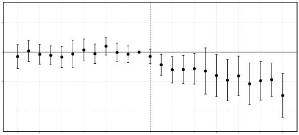

NOTE: figure/graphic rendered as an image from the PDF; its content is not machine-readable text. Caption (if any) follows as the next block.

and state-specific time trends (Table D.6 in the Online Appendix), (5) considering the effect of COVID-19 (Table D.7 in the Online Appendix), (6) excluding the small number of stores affected by multiple incidents, and (7) distinguishing stores located within complexes such as malls or plazas (Table D.9 in the Online Appendix).